# Sistemas de Información Geográfica con R

Modelos con Raster

Edimer David Jaramillo

```r
knitr::opts_chunk$set(fig.align = "center",
                      warning = FALSE,
                      message = FALSE,
                      fig.width = 9)
```

- Notas tomadas del curso [“Sistemas de Información Geográfica en R (SIG en R)” con Derek Corcoran.](https://www.youtube.com/watch?v=9e-zDQPGhBo&ab_channel=DerekCorcoran)

[video not shown]

# Bibliotecas

```r
library(rworldxtra)
library(tidyverse)
library(sf)
library(raster)
```

# Datos Solenopsis

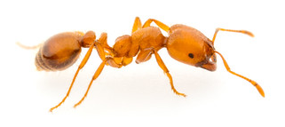

- Ver anexos para obtener código de la base de datos que se carga a continuación.
- Estos datos están en [este directorio de Github.](https://github.com/Edimer/Spatial-Data-Science/blob/main/SIG_R/data/solenopsis.csv)

```r
datos <- read_csv("https://raw.githubusercontent.com/Edimer/Spatial-Data-Science/main/SIG_R/data/solenopsis.csv")
datos
```

| Reference | Study_common_taxon | Site_name | Sampling_effort | Longitude | Latitude | Species | Measurement | Effort_corrected_measurement |
| --- | --- | --- | --- | --- | --- | --- | --- | --- |
| Armbrecht et al. 2006 | Formicidae | FOR_Monteverde | 10 | -75.91937 | 5.115680 | NA | 0 | 0 |
| Armbrecht et al. 2006 | Formicidae | FOR_Monteverde | 10 | -75.91937 | 5.115680 | NA | 0 | 0 |
| Armbrecht et al. 2006 | Formicidae | FOR_Monteverde | 10 | -75.91937 | 5.115680 | NA | 0 | 0 |
| Armbrecht et al. 2006 | Formicidae | FOR_Monteverde | 10 | -75.91937 | 5.115680 | NA | 0 | 0 |
| Armbrecht et al. 2006 | Formicidae | FOR_PlayaBonita | 10 | -75.93722 | 5.123820 | NA | 0 | 0 |
| Armbrecht et al. 2006 | Formicidae | FOR_PlayaBonita | 10 | -75.93722 | 5.123820 | NA | 0 | 0 |
| Armbrecht et al. 2006 | Formicidae | FOR_PlayaBonita | 10 | -75.93722 | 5.123820 | NA | 0 | 0 |
| Armbrecht et al. 2006 | Formicidae | FOR_PlayaBonita | 10 | -75.93722 | 5.123820 | NA | 0 | 0 |
| Armbrecht et al. 2006 | Formicidae | FOR_ElPorvenir | 10 | -75.93176 | 5.125830 | NA | 1 | 1 |
| Armbrecht et al. 2006 | Formicidae | FOR_ElPorvenir | 10 | -75.93176 | 5.125830 | NA | 1 | 1 |

[output cut: 541 more lines]

## Transformación a sf

- En el argumento `coords` se incorpora un vector con la posición de las columnas longitud y latitud, respectivamente.
- El sistema de coordenadas elegido en el siguiente código es el más sencillo de todos, sin embargo, se puede cambiar ([ver clase 01](https://rpubs.com/Edimer/673433)).

```r
# Datos a sf
datos_sf <- datos %>%
  st_as_sf(coords = c(5, 6), crs = "+proj=longlat +ellps=WGS84 +datum=WGS84 +no_defs +towgs84=0,0,0")
```

## Área de estudio

### Área en Colombia

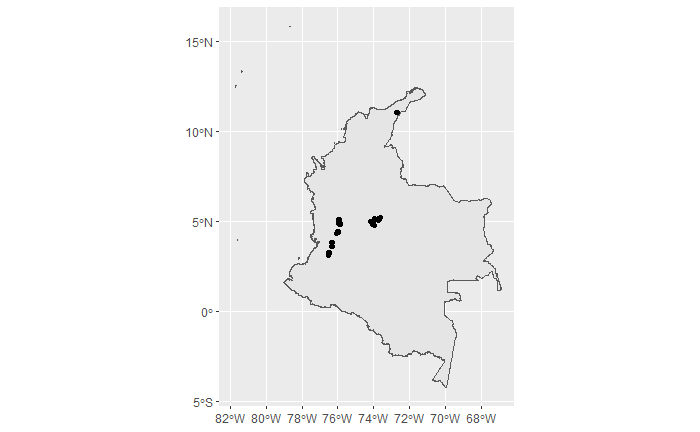

```r
colombia <- raster::getData(name = "GADM", country = "COL", level = 0)
colombia_sf <- st_as_sf(colombia)
colombia_sf %>%
  ggplot() +
  geom_sf() +
  geom_sf(data = datos_sf)
```

### Área específica

- El siguiente mapa corresponde a una región específica de Colombia.

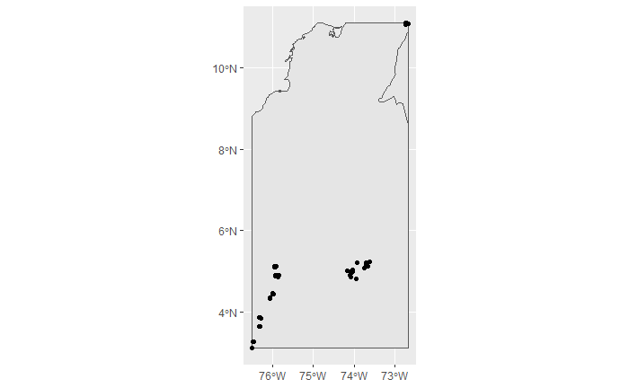

```r
# Mapa del mundo
data("countriesHigh")
mapa <- countriesHigh %>%
  st_as_sf() %>%
  st_crop(datos_sf)
ggplot() +
  geom_sf(data = mapa) +
  geom_sf(data = datos_sf)
```

## Otros mapas

- **Gráfico con color por especie y tamaño por abundancia:** filtro los NA para que no aparezcan en la leyenda.

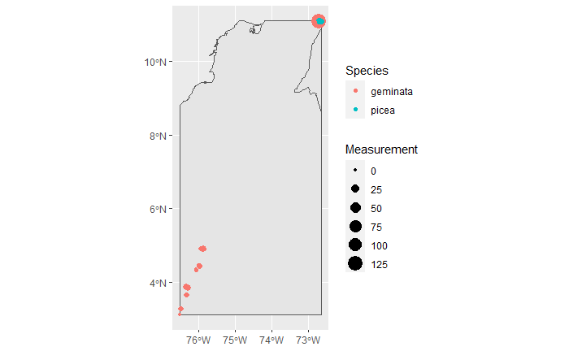

```r
ggplot() +
  geom_sf(data = mapa) +
  geom_sf(data = datos_sf %>% filter(!is.na(Species)),
          aes(color = Species, size = Measurement))
```

- **Gráfico por especie:** filtro los NA para que no aparezcan en la leyenda.

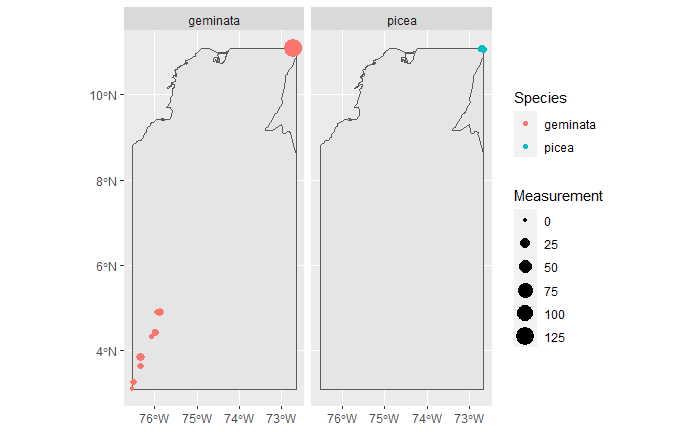

```r
ggplot() +
  geom_sf(data = mapa) +
  geom_sf(data = datos_sf %>% filter(!is.na(Species)),
          aes(color = Species, size = Measurement)) +
  facet_wrap(~Species)
```

## Resumen descriptivo

```r
datos %>%
  group_by(Species) %>%
  summarise(Total = n(),
            AbundanciaPromedio = mean(Measurement),
            MáximoAbundancia = max(Measurement),
            MínimoAbundancia = min(Measurement))
```

| Species | Total | AbundanciaPromedio | MáximoAbundancia | MínimoAbundancia |
| --- | --- | --- | --- | --- |
| geminata | 52 | 6.019231 | 128 | 0 |
| picea | 13 | 2.000000 | 8 | 0 |
| NA | 486 | 1.296296 | 26 | 0 |

# Modelación

## Especie Geminata

- Para los ejemplos siguientes sólo uso la especie *Geminata*. Se observa mayor abundancia en el norte de Colombia.

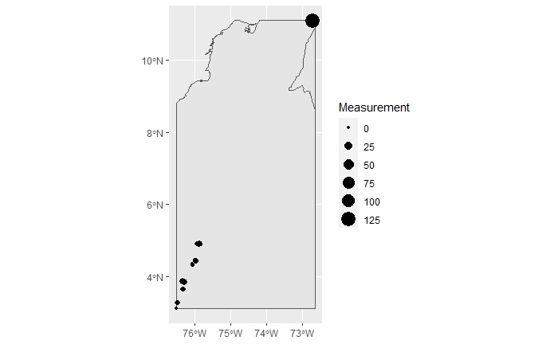

```r
data_geminata <- datos_sf %>% filter(Species == "geminata")
ggplot() +
  geom_sf(data = mapa) +
  geom_sf(data = data_geminata, aes(size = Measurement))
```

## Datos ambientales

```r
clima <- getData("worldclim", var = "bio", res = 2.5)
```

[output not shown]

- **Número de capas o variables bioclimáticas:**

```r
nlayers(clima2)
```

```
[1] 19
```

- Para el ejemplo sólo uso las capas 1, 7, 12, 15 y 19. La elección la hago de forma aleatoria para el ejemplo.

```r
clima3 <- clima2[[c(1, 7, 12, 15, 19)]]
```

## Extracción de datos

- **Variables bioclimáticas:** algunos puntos quedan con valores NA para las variables bioclimáticas.

```r
clima_data <- extract(clima3, data_geminata) %>%
  as.data.frame()
clima_data
```

| bio1 | bio7 | bio12 | bio15 | bio19 |
| --- | --- | --- | --- | --- |
| NA | NA | NA | NA | NA |
| 275 | 130 | 1370 | 71 | 204 |
| 275 | 130 | 1370 | 71 | 204 |
| NA | NA | NA | NA | NA |
| NA | NA | NA | NA | NA |
| NA | NA | NA | NA | NA |
| NA | NA | NA | NA | NA |
| NA | NA | NA | NA | NA |
| NA | NA | NA | NA | NA |
| NA | NA | NA | NA | NA |

[output cut: 42 more lines]

- **Uniendo datos de abundancia con variables bioclimáticas:**

```r
data_final <- data_geminata %>%
  bind_cols(clima_data)
data_final
```

```
Simple feature collection with 52 features and 12 fields
geometry type:  POINT
dimension:      XY
bbox:           xmin: -76.52944 ymin: 3.107725 xmax: -72.65786 ymax: 11.09833
CRS:            +proj=longlat +ellps=WGS84 +datum=WGS84 +no_defs +towgs84=0,0,0
First 10 features:
                             Reference Study_common_taxon Site_name Sampling_effort  Species
1  Dominguez-Haydar and Armbrecht 2010         Formicidae      0yrs              20 geminata
2  Dominguez-Haydar and Armbrecht 2010         Formicidae      1yrs              20 geminata
3  Dominguez-Haydar and Armbrecht 2010         Formicidae      2yrs              20 geminata
4  Dominguez-Haydar and Armbrecht 2010         Formicidae      4yrs              20 geminata
5  Dominguez-Haydar and Armbrecht 2010         Formicidae      6yrs              20 geminata
6  Dominguez-Haydar and Armbrecht 2010         Formicidae      7yrs              20 geminata
7  Dominguez-Haydar and Armbrecht 2010         Formicidae      8yrs              20 geminata
8  Dominguez-Haydar and Armbrecht 2010         Formicidae     12yrs              20 geminata
```

[output cut: 24 more lines]

## Relaciones

- **Nota:** para esta especie en particular el número de datos es bajo.

### Lineales

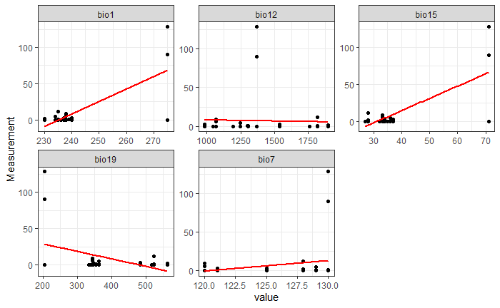

```r
data_final %>%
  as.data.frame() %>%
  dplyr::select(bio1:bio19, Measurement) %>%
  gather(key = "key", value = "value", -Measurement)  %>%
  ggplot(aes(x = value, y = Measurement)) +
  facet_wrap(~key, scales = "free", ncol = 3) +
  geom_point() +
  geom_smooth(method = "lm", color = "red", se = FALSE) +
  theme_bw()
```

### Lineales (Logaritmos de abundancia)

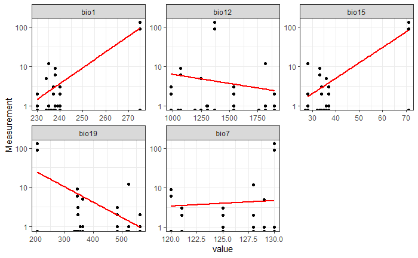

```r
data_final %>%
  as.data.frame() %>%
  dplyr::select(bio1:bio19, Measurement) %>%
  gather(key = "key", value = "value", -Measurement)  %>%
  ggplot(aes(x = value, y = Measurement)) +
  facet_wrap(~key, scales = "free", ncol = 3) +
  geom_point() +
  geom_smooth(method = "lm", color = "red", se = FALSE) +
  scale_y_log10() +
  theme_bw()
```

## Modelos

### GLM Poisson

```r
modelo1 <- glm(Measurement ~ bio1 + bio7 + bio12 + bio15 + bio19,
               data = data_final, family = "poisson")
summary(modelo1)
```

```
Call:
glm(formula = Measurement ~ bio1 + bio7 + bio12 + bio15 + bio19,
    family = "poisson", data = data_final)

Deviance Residuals:
     Min        1Q    Median        3Q       Max
-12.0620   -1.6910   -1.2246    0.5594    5.8436

Coefficients:
             Estimate Std. Error z value Pr(>|z|)
(Intercept) 55.808756  23.859812   2.339 0.019334 *
bio1        -0.080275   0.075201  -1.067 0.285763
bio7        -0.326484   0.084470  -3.865 0.000111 ***
bio12        0.008604   0.002602   3.307 0.000942 ***
bio15        0.087892   0.065417   1.344 0.179087
bio19       -0.024663   0.008683  -2.840 0.004506 **
---
Signif. codes:  0 ‘***’ 0.001 ‘**’ 0.01 ‘*’ 0.05 ‘.’ 0.1 ‘ ’ 1

(Dispersion parameter for poisson family taken to be 1)

    Null deviance: 1169.74  on 38  degrees of freedom
Residual deviance:  309.68  on 33  degrees of freedom
  (13 observations deleted due to missingness)
AIC: 378.12

Number of Fisher Scoring iterations: 6
```

- **Residuales:**

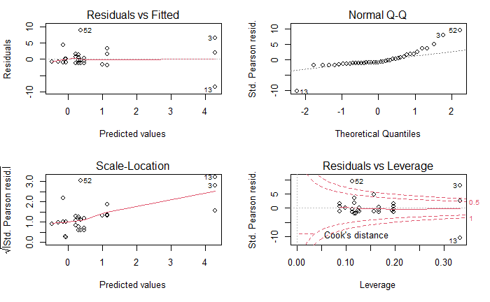

```r
par(mfrow = c(2,2))
plot(modelo1)
```

### GLM Poisson + Polinomio 2

```r
modelo2 <- glm(Measurement ~ I(bio1^2) + bio7 + bio12 + I(bio15^2) + bio19,
               data = data_final, family = "poisson")
summary(modelo2)
```

```
Call:
glm(formula = Measurement ~ I(bio1^2) + bio7 + bio12 + I(bio15^2) +
    bio19, family = "poisson", data = data_final)

Deviance Residuals:
     Min        1Q    Median        3Q       Max
-12.0616   -1.7216   -1.3000    0.5815    5.8441

Coefficients:
              Estimate Std. Error z value Pr(>|z|)
(Intercept) 43.8725633 15.4543461   2.839 0.004528 **
I(bio1^2)   -0.0001434  0.0001564  -0.917 0.358979
bio7        -0.3003849  0.0798584  -3.761 0.000169 ***
bio12        0.0076670  0.0027049   2.834 0.004590 **
I(bio15^2)   0.0008692  0.0007621   1.141 0.254019
bio19       -0.0224261  0.0092793  -2.417 0.015658 *
---
Signif. codes:  0 ‘***’ 0.001 ‘**’ 0.01 ‘*’ 0.05 ‘.’ 0.1 ‘ ’ 1

(Dispersion parameter for poisson family taken to be 1)

    Null deviance: 1169.74  on 38  degrees of freedom
Residual deviance:  310.28  on 33  degrees of freedom
  (13 observations deleted due to missingness)
AIC: 378.72

Number of Fisher Scoring iterations: 6
```

- **Residuales:**

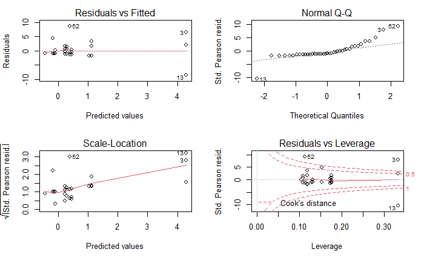

```r
par(mfrow = c(2,2))
plot(modelo2)
```

### GAM

```r
library(mgcv)
modelo3 <- gam(Measurement ~ s(bio1, k = 4) + s(bio7, k = 5) +
                 bio12 + bio15 + bio19 + bio1 + bio7,
               data = data_final, family = "poisson")
summary(modelo3)
```

```
Family: poisson
Link function: log

Formula:
Measurement ~ s(bio1, k = 4) + s(bio7, k = 5) + bio12 + bio15 +
    bio19 + bio1 + bio7

Parametric coefficients:
            Estimate Std. Error z value Pr(>|z|)
(Intercept)   0.0000     0.0000      NA       NA
bio12         0.2318     1.2777   0.181    0.856
bio15         4.0208     5.0339   0.799    0.424
bio19        -0.6589     4.8372  -0.136    0.892
bio1         -4.5917    23.6431  -0.194    0.846
bio7          7.1399    46.0812   0.155    0.877

Approximate significance of smooth terms:
          edf Ref.df Chi.sq p-value
s(bio1) 0.889  1.019  0.534   0.505
s(bio7) 3.963  3.966  2.168   0.667

Rank: 11/13
R-sq.(adj) =  0.495   Deviance explained =   76%
UBRE = 6.6983  Scale est. = 1         n = 39
```

- **Residuales:**

```
Method: UBRE   Optimizer: outer newton
full convergence after 11 iterations.
Gradient range [2.235383e-06,9.044007e-06]
(score 6.698331 & scale 1).
Hessian positive definite, eigenvalue range [9.541386e-06,0.0005525887].
Model rank =  11 / 13

Basis dimension (k) checking results. Low p-value (k-index<1) may
indicate that k is too low, especially if edf is close to k'.

           k'   edf k-index p-value
s(bio1) 3.000 0.889    0.99    0.49
s(bio7) 4.000 3.963    1.22    0.94
```

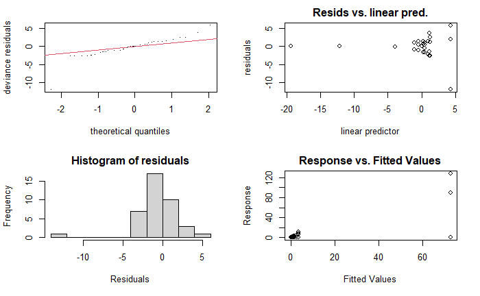

```r
par(mfrow = c(2, 2))
gam.check(modelo3)
```

### Mejor Modelo

```r
AIC(modelo1, modelo2, modelo3)
```

|  | df | AIC |
| --- | --- | --- |
| modelo1 | 6.000000 | 378.1210 |
| modelo2 | 6.000000 | 378.7156 |
| modelo3 | 9.852489 | 356.6724 |

## Predicciones

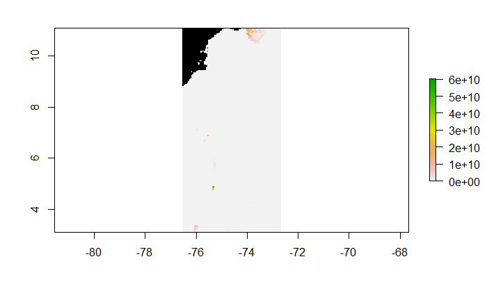

```r
prediccion <- predict(clima3, modelo2, type = "response")
plot(prediccion, colNA = "black")
```

- **Mapa con ggplot2:**

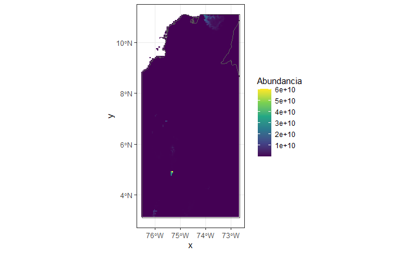

```r
prediccion_df <- prediccion %>%
  as("SpatialPixelsDataFrame") %>%
  as.data.frame() %>%
  rename(Abundancia = layer)

ggplot() +
  geom_tile(data = prediccion_df, aes(x = x, y = y, fill = Abundancia)) +
  geom_sf(data = mapa, alpha = 0) +
  scale_fill_viridis_c() +
  theme_bw()
```

## Predicciones futuras

- **Imágenes futuras:** las mismas con las cuales se entrenó el modelo.

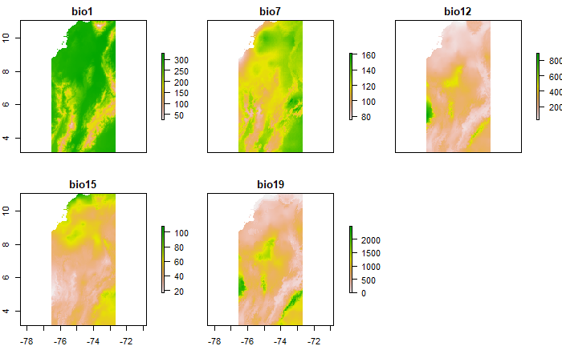

```r
futuro <- raster::getData("CMIP5", var = "bio", res = 2.5, rcp = 85,
                          model = "HD", year = 70) %>%
  crop(data_geminata)

futuro <- futuro[[c(1, 7, 12, 15, 19)]]
names(futuro) <- c("bio1", "bio7", "bio12", "bio15", "bio19")
plot(futuro)
```

- **Mapa de predicción de abundancia:**

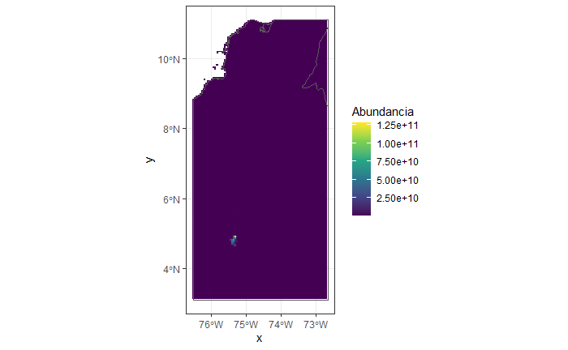

```r
prediccion_futura <- predict(futuro, modelo2, type = "response")

prediccion_df_futuro <- prediccion_futura %>%
  as("SpatialPixelsDataFrame") %>%
  as.data.frame() %>%
  rename(Abundancia = layer)

ggplot() +
  geom_tile(data = prediccion_df_futuro, aes(x = x, y = y, fill = Abundancia)) +
  geom_sf(data = mapa, alpha = 0) +
  scale_fill_viridis_c() +
  theme_bw()
```

# Anexos

- En el ejemplo de clase se trabaja con la especie Bombus affinis (abejorros), sin embargo, obtuve directamente la base de datos de [PREDICTS database](https://data.nhm.ac.uk/dataset/the-2016-release-of-the-predicts-database) y voy a trabajar con el género de hormigas [*Solenopsis*,](https://es.wikipedia.org/wiki/Solenopsis) también conocida como hormiga colorada o de fuego..
- En este caso filtro información sólo para Colombia.
- Se filtran datos sólo de abundancia de especies.
- Mantengo sólo las siguientes variables:
  - **Reference:** referencia del estudio
  - **Study_common_taxon:** taxón
  - **Site_name:** nombre de sitio
  - Sampling_effort
  - Longitude
  - Latitude
  - Species
  - **Measurement:** medida de abundancia
  - Effort_corrected_measurement

```r
# Base de datos total con más de 3 millones de registros
datos_total <- fread("database.csv", encoding = "UTF-8")
# Filtro solenopsis para Colombia: 551 registros de abundancia
datos_colombia <- datos_total %>%
  filter(Country == "Colombia") %>%
  filter(Genus == "Solenopsis") %>%
  filter(Diversity_metric_type == "Abundance") %>%
  select(Reference, Study_common_taxon, Site_name, Sampling_effort,
         Longitude, Latitude, Species, Measurement,
         Effort_corrected_measurement)
# Exportando datos de solenopsis
write.csv(datos_colombia, file = "solenopsis.csv", row.names = FALSE,
          fileEncoding = "UTF-8")
```